# Modeling and Statistics

## Is this a statistics class or not???

## Sampling from data

## Our best friend the titanic dataset

```r
head(titanic)
```

```
##   Survived Pclass                                               Name    Sex Age
## 1        0      3                             Mr. Owen Harris Braund   male  22
## 2        1      1 Mrs. John Bradley (Florence Briggs Thayer) Cumings female  38
## 3        1      3                              Miss. Laina Heikkinen female  26
## 4        1      1        Mrs. Jacques Heath (Lily May Peel) Futrelle female  35
## 5        0      3                            Mr. William Henry Allen   male  35
## 6        0      3                                    Mr. James Moran   male  27
##   Siblings.Spouses.Aboard Parents.Children.Aboard    Fare
## 1                       1                       0  7.2500
## 2                       1                       0 71.2833
## 3                       0                       0  7.9250
## 4                       1                       0 53.1000
## 5                       0                       0  8.0500
## 6                       0                       0  8.4583
```

## Sampling from data

Let’s take a sample of 10 passengers:

```r
?sample
```

## Sampling from data

Let’s take a sample of 10 passengers:

```r
sample(10)
```

## Sampling from data

Let’s take a sample of 10 passengers:

```r
sample(10)
```

```
##  [1]  2 10  6  5  4  1  8  9  7  3
```

## Sampling from data

Let’s take a sample of 10 passengers:

```r
sample(titanic$Name, 10)
```

```
##  [1] Mr. Konrad Mathias Reiersen Hagland  Mr. Mohamed Badt
##  [3] Miss. Agda Thorilda Viktoria Lindahl Mr. Alfred George John Rush
##  [5] Mr. Alfred Johnson                   Mr. Ernesti Arvid Panula
##  [7] Mr. Lee Bing                         Miss. Eugenie Baclini
##  [9] Mr. John Hatfield Cribb              Master. Richard F Becker
## 887 Levels: Capt. Edward Gifford Crosby ... the Countess. of (Lucy Noel Martha Dyer-Edwards) Rothes
```

## Sampling from data

Let’s take a sample of 10 passengers:

```r
sample(1:nrow(titanic), 10)
```

```
##  [1] 757 237 397 270 588  90 772 330 777 801
```

## Sampling from data

Let’s take a sample of 10 passengers:

```r
rand <- sample(1:nrow(titanic), 10)
titanic[rand,]
```

```
##     Survived Pclass                               Name    Sex Age
## 493        0      3               Mr. Gerious Yousseff   male  26
## 841        0      3                 Mr. Jeso Culumovic   male  17
## 248        1      1       Mr. Richard Leonard Beckwith   male  37
## 242        0      2     Mr. Reginald Charles Coleridge   male  29
## 315        1      2 Mrs. Sinai (Miriam Sternin) Kantor female  24
## 44         1      3       Miss. Margaret Delia Devaney female  19
## 883        0      2               Rev. Juozas Montvila   male  27
## 119        0      3   Miss. Ellis Anna Maria Andersson female   2
## 238        0      2     Mr. Frederick William Pengelly   male  19
## 326        1      2             Mrs. (Ada E Hall) Ball female  36
##     Siblings.Spouses.Aboard Parents.Children.Aboard    Fare
## 493                       0                       0 14.4583
## 841                       0                       0  8.6625
## 248                       1                       1 52.5542
## 242                       0                       0 10.5000
## 315                       1                       0 26.0000
## 44                        0                       0  7.8792
## 883                       0                       0 13.0000
## 119                       4                       2 31.2750
## 238                       0                       0 10.5000
## 326                       0                       0 13.0000
```

## Sampling from data

Let’s take a sample of 10 passengers:

```r
titanic %>%
  sample_n(10)
```

```
##    Survived Pclass                           Name    Sex  Age
## 1         0      2       Mr. Arne Jonas Fahlstrom   male 18.0
## 2         1      1     Miss. Susan Parker Ryerson female 21.0
## 3         0      3           Miss. Malake Attalah female 17.0
## 4         0      3            Master. Eugene Rice   male  2.0
## 5         0      3    Miss. Doolina Margaret Ford female 21.0
## 6         0      3            Miss. Hileni Zabour female 14.5
## 7         0      1              Mr. George Wright   male 62.0
## 8         1      3                    Mr. Ali Lam   male 37.0
## 9         0      3                  Mr. Amin Saad   male 30.0
## 10        0      1 Jonkheer. John George Reuchlin   male 38.0
##    Siblings.Spouses.Aboard Parents.Children.Aboard     Fare
## 1                        0                       0  13.0000
## 2                        2                       2 262.3750
## 3                        0                       0  14.4583
## 4                        4                       1  29.1250
## 5                        2                       2  34.3750
## 6                        1                       0  14.4542
## 7                        0                       0  26.5500
## 8                        0                       0  56.4958
## 9                        0                       0   7.2292
## 10                       0                       0   0.0000
```

## Probability distributions

## Probability distributions

Recall from your previous statistics classes…

- A **random variable** is a value we don’t know until we take a **sample**.
  - Coin flip: Could be heads (0) or tails (1)
  - Person’s height: Could be anything from 0 feet to 20 feet.
- The possible values of a random variable, and how likely they are, is determined by the **distribution**.
  - Coin flip has 50% chance of heads, 50% chance of tails
  - Likelihood of heights follow a bell curve around 5 foot 7.

## Probability distributions

- Some distributions have names. For this class, you need to know:
  - Uniform
  - Normal
  - t-distribution
  - Binomial
  - Chi-Square
- (What you need to know: basic idea of when it is appropriate to use them.)

## Distributions in R

- r for **random sampling**: generate a random value from the distribution

```r
runif(3)
```

```
## [1] 0.8070017 0.7636908 0.7879694
```

```r
runif(3, min = 10, max = 20)
```

```
## [1] 12.80584 18.21571 15.50217
```

```r
rnorm(3)
```

```
## [1]  0.5285655 -1.0450814  0.9760472
```

```r
rnorm(3, mean = -100, sd = 50)
```

```
## [1]  -74.8754 -111.7185 -133.8962
```

## Distributions in R

- r for **random sampling**: generate a random value from the distribution

```r
rt(3, df = 11)
```

```
## [1] -0.7883882  1.3004042 -0.5778110
```

```r
rbinom(3, size = 10, prob = 0.7)
```

```
## [1]  9 10  8
```

```r
rchisq(3, df = 11)
```

```
## [1] 11.74673 10.04903 12.75587
```

## Distributions in R

- p for **probability**: cumulative distribution function, i.e. compute P(X < x)

```r
pnorm(1.5)
```

```
## [1] 0.9331928
```

```r
pnorm(70, mean = 67, sd = 3)
```

```
## [1] 0.8413447
```

```r
1 - pnorm(70, mean = 67, sd = 3)
```

```
## [1] 0.1586553
```

## Exercise

- What is the probability that a Chi-Square distribution with 35 degrees of freedom gives a value of 25 or less?
- What is the probability that 10 coin tosses give 6 or more heads?

## Distributions in R

- q for **quantile**: given a probability p, compute the x-value such that P(X < x) = p.

```r
qnorm(.95)
```

```
## [1] 1.644854
```

```r
qnorm(.95, mean = 67, sd = 3)
```

```
## [1] 71.93456
```

## Exercise

- If I randomly sample a number between 16 and 22, I can be 80% sure my number will be less than what?
- What is the critical value for a 1-sided t-test at the 0.05 significance level, with a sample size of 50?

## Distributions in R

- d for **density**: compute the height of the mass or density curve/function
  - Continuous distributions: usually meaningless

## Exercise

- What is the probability of getting exactly 12 heads in 20 coin tosses?

## Let’s practice!

## Let’s practice!

- WITHOUT USING R, try to predict the following:

```r
punif(0.674)

pnorm(2)
qnorm(.975)

pchisq(0, df = 12)

qt(10, df = 16)

dbinom(1, size = 2, prob = .87)
pbinom(1, size = 2, prob = .87)
```

## Let’s practice!

```r
punif(0.674)
```

```
## [1] 0.674
```

```r
pnorm(2)
```

```
## [1] 0.9772499
```

```r
qnorm(.975)
```

```
## [1] 1.959964
```

## Let’s practice!

```r
pchisq(0, df = 12)
```

```
## [1] 0
```

```r
qt(10, df = 16)
```

```
## [1] NaN
```

```r
dbinom(1, size = 2, prob = .87)
```

```
## [1] 0.2262
```

```r
pbinom(1, size = 2, prob = .87)
```

```
## [1] 0.2431
```

## Plotting distributions

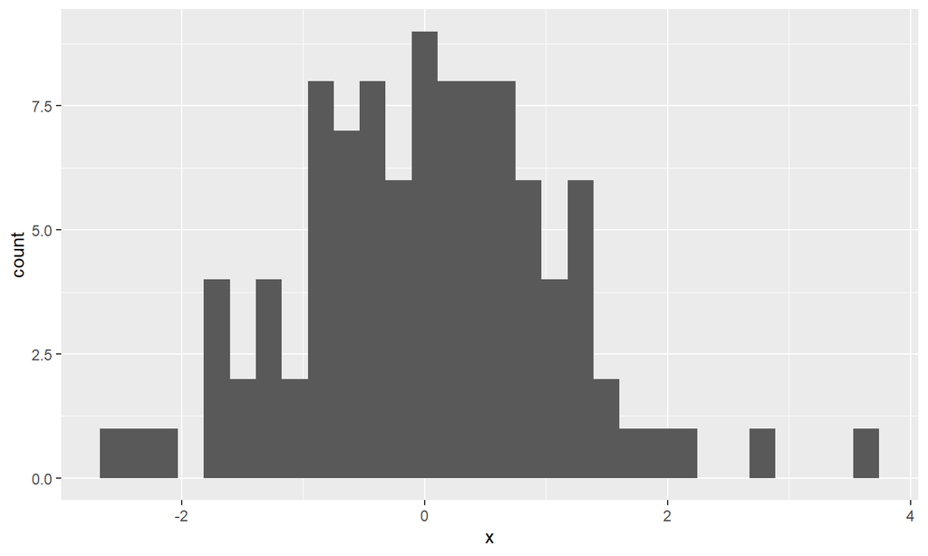

```r
my_samples <- data.frame(x = rnorm(100))

ggplot(my_samples, aes(x)) + geom_histogram()
```

## Plotting distributions

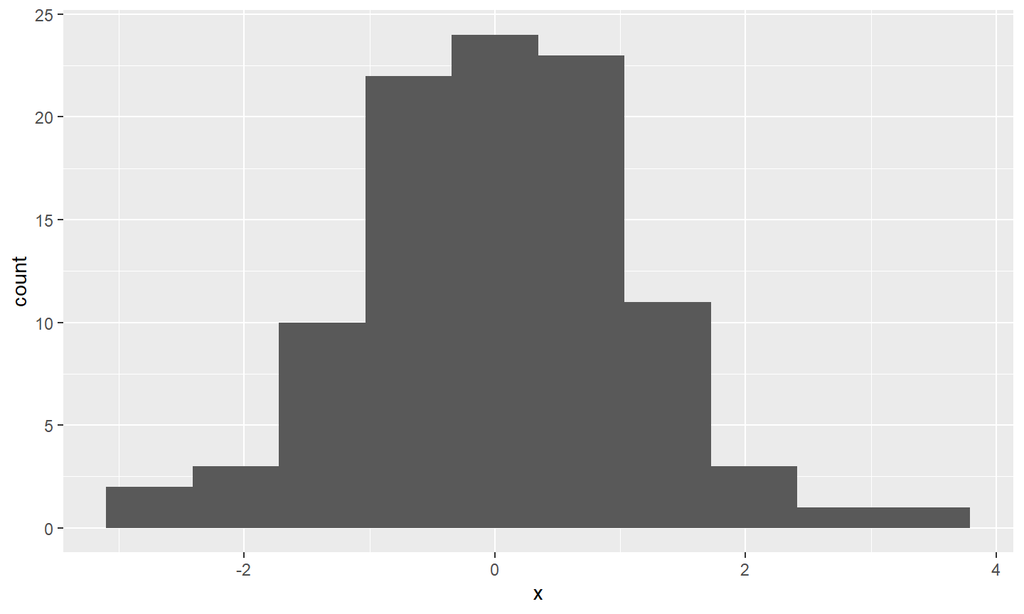

```r
ggplot(my_samples, aes(x)) +
  geom_histogram(bins = 10)
```

## Plotting distributions

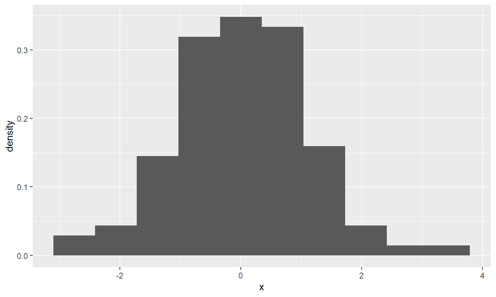

```r
ggplot(my_samples, aes(x)) +
  geom_histogram(bins = 10, aes(y = ..density..))
```

## Plotting distributions

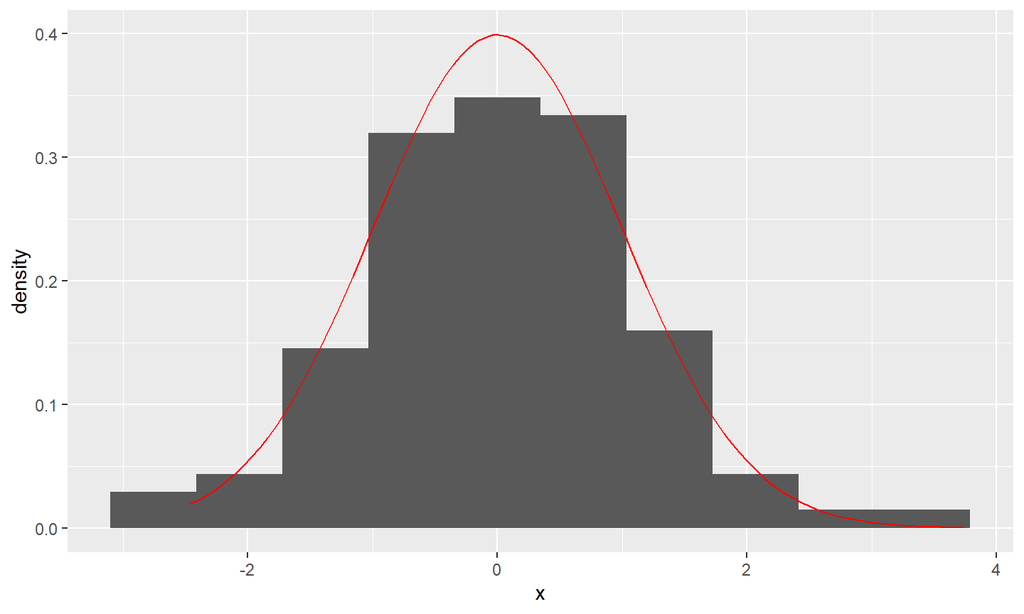

```r
ggplot(my_samples, aes(x)) +
  geom_histogram(bins = 10, aes(y = ..density..)) +
  stat_function(fun=dnorm, col = "red")
```

## Basic hypothesis tests in R

## Interlude: Review on t-tests and chi-square tests.

## t-tests

We would like to test if men or women paid more on the Titanic.

```r
?t.test
```

## t-tests

We would like to test if men or women paid more on the Titanic.

```r
t.test(Fare ~ Sex, data = titanic)
```

```
##
##  Welch Two Sample t-test
##
## data:  Fare by Sex
## t = 5.0404, df = 507.22, p-value = 6.474e-07
## alternative hypothesis: true difference in means is not equal to 0
## 95 percent confidence interval:
##  11.50016 26.19161
## sample estimates:
## mean in group female   mean in group male
##             44.47982             25.63394
```

## Tidying it up

That output is not tidy!

```r
my_test <- t.test(Fare ~ Sex, data = titanic)
tidy(my_test)  ## requires the 'broom' package!
```

```
## # A tibble: 1 x 10
##   estimate estimate1 estimate2 statistic p.value parameter conf.low conf.high
##      <dbl>     <dbl>     <dbl>     <dbl>   <dbl>     <dbl>    <dbl>     <dbl>
## 1     18.8      44.5      25.6      5.04 6.47e-7      507.     11.5      26.2
## # … with 2 more variables: method <chr>, alternative <chr>
```

## Tidying it up

Why is tidying nice? For easily referencing the info later.

```r
my_test <- tidy(t.test(Fare ~ Sex, data = titanic))
my_test$p.value
```

```
## [1] 6.473616e-07
```

```r
1 - pt(my_test$statistic, df = nrow(titanic))
```

```
## [1] 2.81526e-07
```

## Chisquared Tests

What input is expected?

```r
?chisq.test
```

## Chisquared Tests

```r
titanic %>% count(Sex, Pclass)
```

```
## # A tibble: 6 x 3
##   Sex    Pclass     n
##   <fct>   <int> <int>
## 1 female      1    94
## 2 female      2    76
## 3 female      3   144
## 4 male        1   122
## 5 male        2   108
## 6 male        3   343
```

## Chisquared Tests

```r
titanic %>%
  count(Sex, Pclass) %>%
  spread(key = Sex, value = n)
```

```
## # A tibble: 3 x 3
##   Pclass female  male
##    <int>  <int> <int>
## 1      1     94   122
## 2      2     76   108
## 3      3    144   343
```

## Chisquared Tests

```r
titanic %>%
  count(Sex, Pclass) %>%
  spread(key = Sex, value = n) %>%
  select(female, male)
```

```
## # A tibble: 3 x 2
##   female  male
##    <int> <int>
## 1     94   122
## 2     76   108
## 3    144   343
```

## Chisquared Tests

```r
titanic %>%
  count(Sex, Pclass) %>%
  spread(key = Sex, value = n) %>%
  select(female, male) %>%
  chisq.test()
```

```
##
##  Pearson's Chi-squared test
##
## data:  .
## X-squared = 16.272, df = 2, p-value = 0.0002929
```

## Chisquared Tests

```r
titanic %>%
  count(Sex, Pclass) %>%
  spread(key = Sex, value = n) %>%
  select(female, male) %>%
  chisq.test() %>%
  tidy()
```

```
## # A tibble: 1 x 4
##   statistic  p.value parameter method
##       <dbl>    <dbl>     <int> <chr>
## 1      16.3 0.000293         2 Pearson's Chi-squared test
```

## Many models

## List-columns

A dataset…. with a variable… of datasets?

```r
titanic %>% group_by(Pclass) %>% nest()
```

```
## # A tibble: 3 x 2
## # Groups:   Pclass [3]
##   Pclass           data
##    <int> <list<df[,7]>>
## 1      3      [487 × 7]
## 2      1      [216 × 7]
## 3      2      [184 × 7]
```

## Yo dawg, I heard you like datasets…

[figure not shown]

dawg

## Multiple tests

```r
t_by_class <- titanic %>%
  group_by(Pclass) %>%
  nest() %>%
  arrange(Pclass)

my_tests <- map_df(t_by_class$data,
                   ~tidy(t.test(Fare ~ Sex, data = .x)))

my_tests
```

```
## # A tibble: 3 x 10
##   estimate estimate1 estimate2 statistic p.value parameter conf.low conf.high
##      <dbl>     <dbl>     <dbl>     <dbl>   <dbl>     <dbl>    <dbl>     <dbl>
## 1    38.9      106.       67.2      3.74 2.36e-4      204.    18.4      59.4
## 2     2.23      22.0      19.7      1.17 2.43e-1      182.    -1.53      5.98
## 3     3.42      16.1      12.7      2.95 3.51e-3      270.     1.14      5.71
## # … with 2 more variables: method <chr>, alternative <chr>
```